# Ch 5 exercises

The aim of these exercises is to help you get comfortable with running exploratory data analysis - taking a data set and a potential model, and evaluating whether the two are compatible. This activity will be part of most of the exercises in the later chapters. Particular things to look for are:

- Does the data set have extreme values?
- How do you identify those values?
  - Are the observations legitimate or mistakes?
  - Are extreme values influential?
- What statistical model is proposed for this data set?
  - What are the important assumptions?
  - How can you evaluate whether those assumptions are satisfied?
  - If they aren’t satisfied, what are your options?

Exploratory data analysis can be counter-intuitive. We emphasise its value as something to do before going ahead with fitting the model, assessing parameters, and testing hypothesis, **but** some assumptions can only be assessed by fitting the model. At this stage, we’re aiming to fit the model without bothering to look at parameter interests, confidence intervals, or P-values, but software doesn’t always make this easy. We’re trying to avoid the temptation of P-hacking or its equivalent - fitting a model that will give us results, rather than one that is appropriate for the particular data set. If you wanted to be super-rigourous about this step, you could write some Rmarkdown code where the results of model-fitting are suppressed (using RESULTS= ‘Hide’, etc.) and you just generate, e.g. residual plots!

## A

Continue with the La Boeuf et al. elephant seal example from Chapter 4’s exercises.

**For the linear model you’ve specified, what are the assumptions?**

> Linearity

> Variances consistent across the range of the predictor

> Independence

**Open the data file and check those assumptions.**

```r
df <- read.csv("data/leboeuf.csv")
head(df,10)
```

|  | male | departwt | distance | FFAduration | durationto | durationfrom |
| --- | --- | --- | --- | --- | --- | --- |
| 1 | Pop | NA | 534 | 31 | 18 | 11 |
| 2 | Alt | 973 | 755 | 89 | 9 | 8 |
| 3 | Pro | 977 | 1210 | 77 | 12 | 18 |
| 4 | Hal | 1121 | NA | NA | NA | NA |
| 5 | Blu | NA | 1297 | 76 | 19 | 25 |
| 6 | Dua | 996 | 1487 | 68 | 18 | 23 |
| 7 | Rov | 1100 | 2073 | 69 | 29 | 25 |
| 8 | Ric | 1068 | 2181 | 46 | 21 | 42 |
| 9 | Ori | 1097 | NA | NA | NA | NA |
| 10 | Jer | 1199 | NA | NA | NA | NA |

```r
NA
```

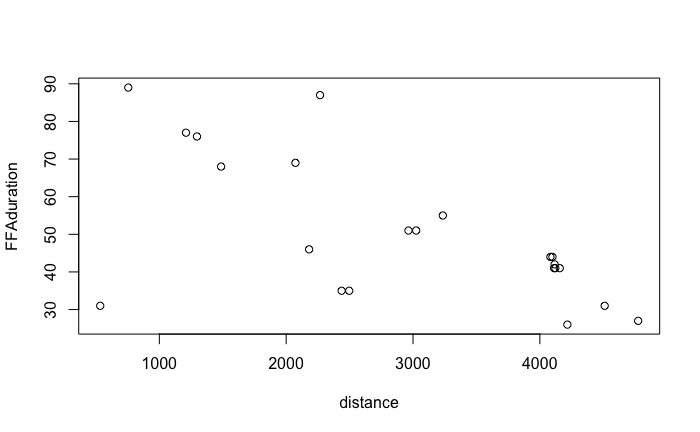

```r
plot(data = df, FFAduration ~ distance)
```

The data also include information on departure weight. Have a look to see if that variable might also be linked to foraging duration, and whether it might also be linked to distance travelled.

*Hint: here’s your chance at a scatterplot matrix*

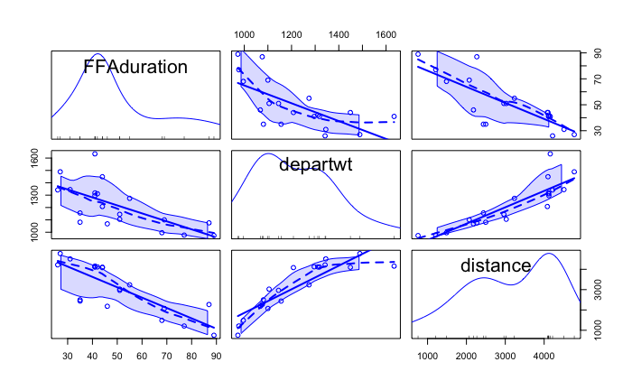

```r
scatterplotMatrix(data = df, ~ FFAduration + departwt + distance)
```

> At first pass, relationship between FFA duration and distance, and also between distance and departwt.

> Both relationships seem nonlinear and flatten at higher masses. Try log weight (or could use a common power, such as 3/4)

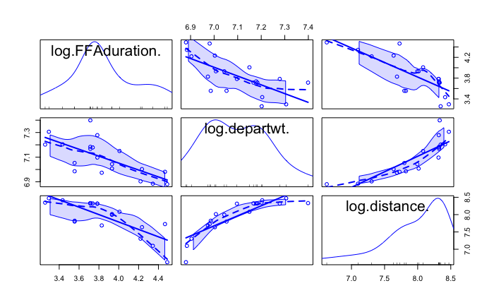

```r
scatterplotMatrix(data = df, ~ log(FFAduration) + log(departwt) + log(distance))
```

We’ll come back and look at this dataset again in Chapter 8 exercises.

## B

Continue with the Peake and Quinn example from Chapter 4’s exercises, the relationship between the number of individuals and number of species (response variables).

**For the linear model you’ve specified, what are the assumptions?**

Open the **data file** **and check those assumptions.**

```r
df <- read.csv("data/peakquinn.csv")
head(df,10)
```

|  | area | indiv | species |
| --- | --- | --- | --- |
| 1 | 516 | 18 | 3 |
| 2 | 469 | 60 | 7 |
| 3 | 462 | 57 | 6 |
| 4 | 939 | 100 | 8 |
| 5 | 1357 | 48 | 10 |
| 6 | 1774 | 118 | 9 |
| 7 | 1686 | 148 | 10 |
| 8 | 1786 | 214 | 11 |
| 9 | 3090 | 225 | 16 |
| 10 | 3980 | 283 | 9 |

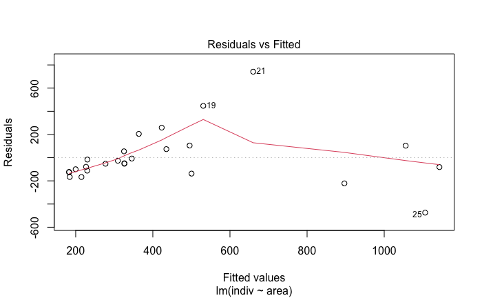

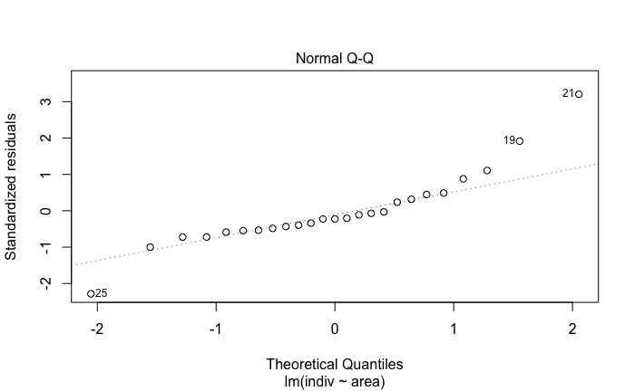

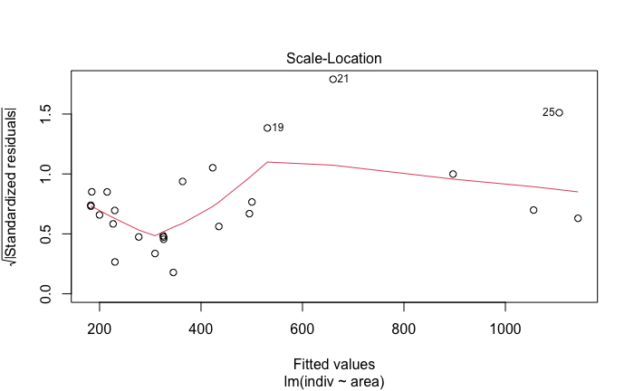

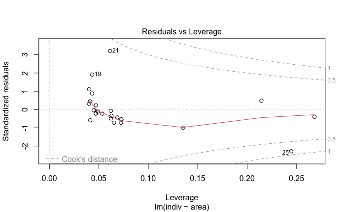

```r
lm1 <- lm(indiv ~ area, data = df)
plot(lm1)
```

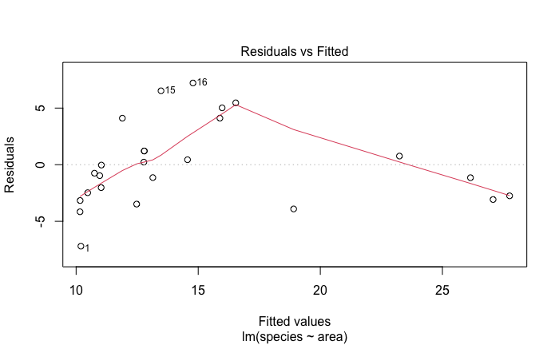

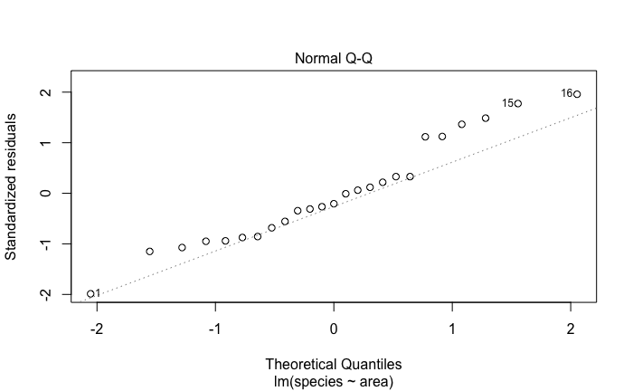

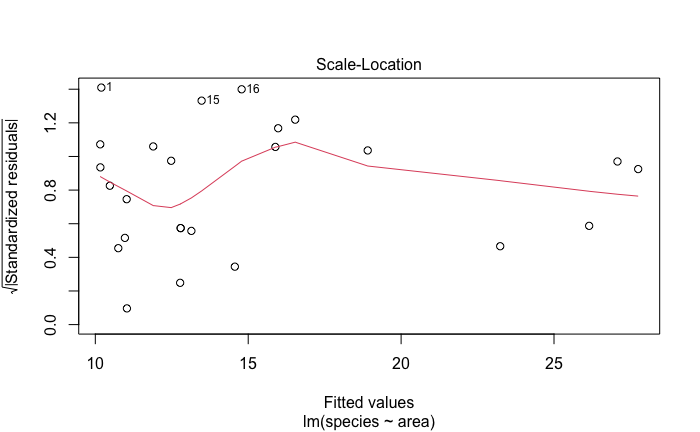

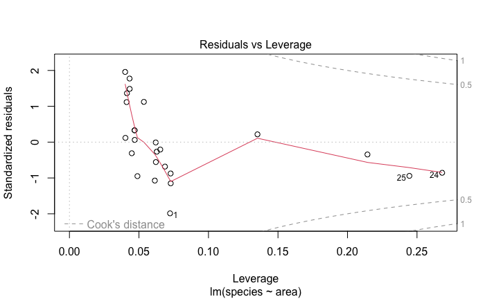

```r
lm2 <- lm(species ~ area, data = df)
plot(lm2)
```

> Start by logging area

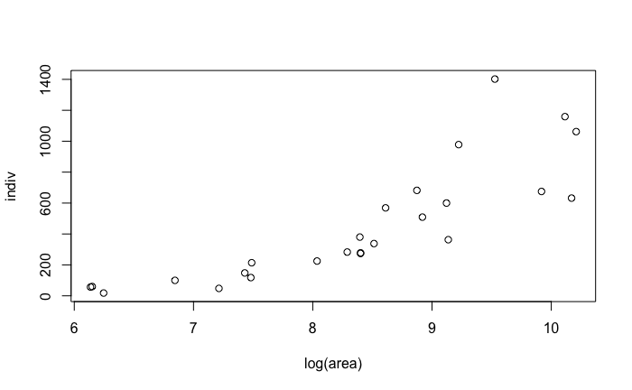

```r
plot(indiv ~ log(area), data = df)
```

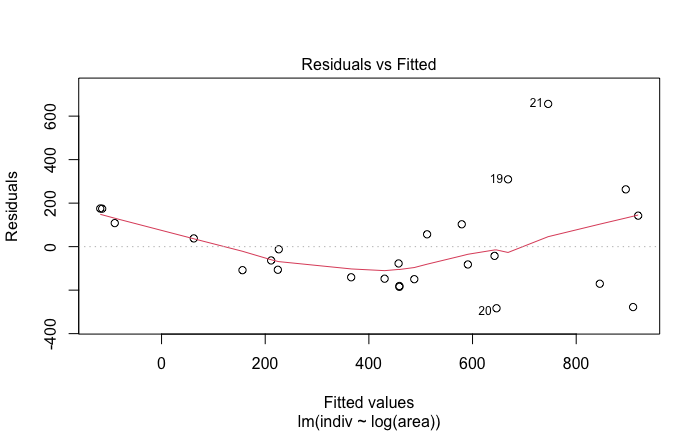

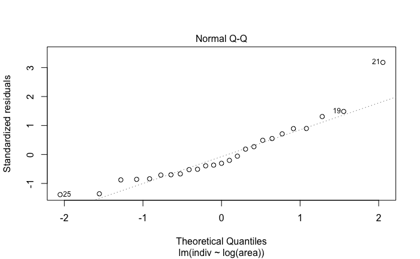

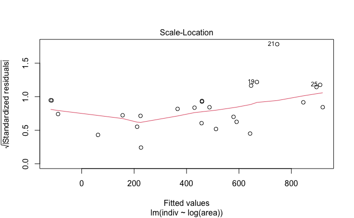

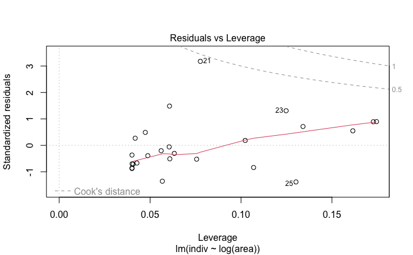

```r
lm3 <- lm(indiv ~ log(area), data = df)
plot(lm3)
```

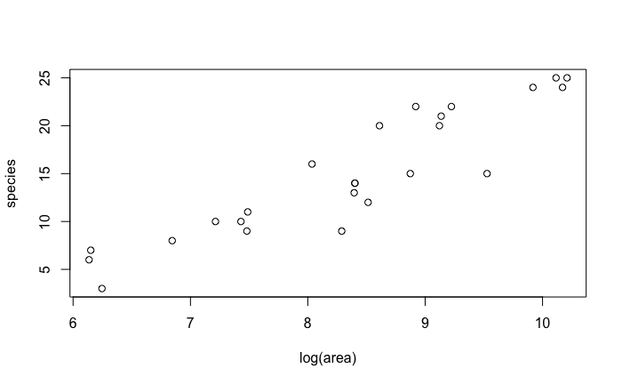

```r
plot(species ~ log(area), data = df)
```

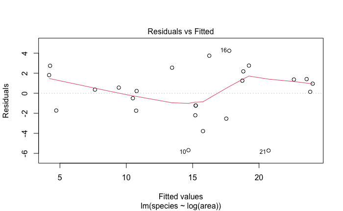

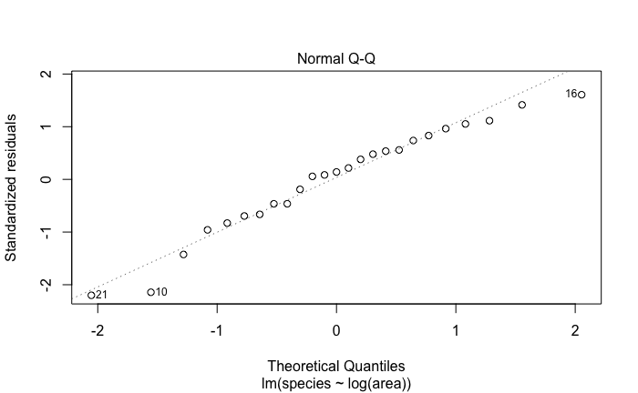

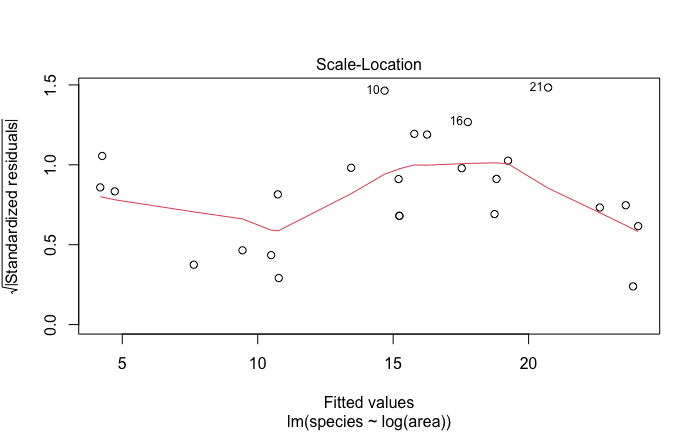

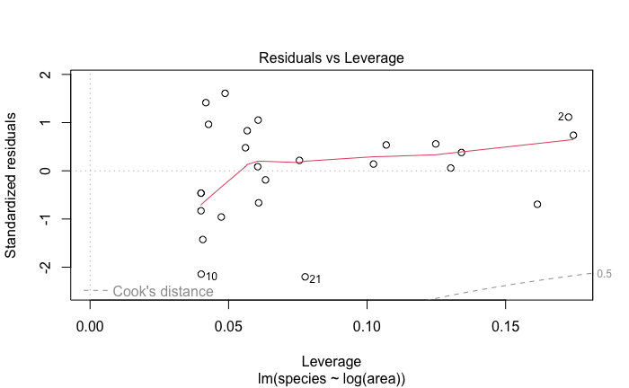

```r
lm4 <- lm(species ~ log(area), data = df)
plot(lm4)
```

> Species plot looks fine now; indiv still non-linear, but in opposite direction. Try logging response as well

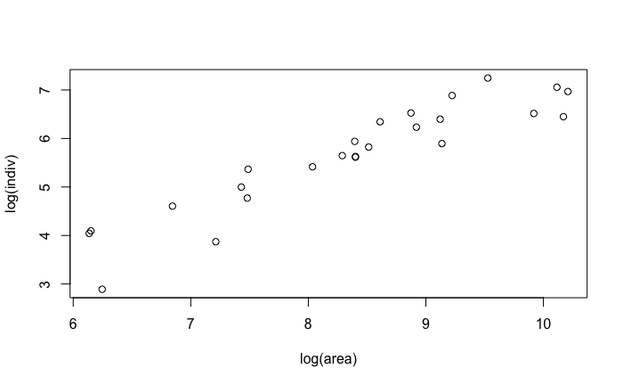

```r
plot(log(indiv) ~ log(area), data = df)
```

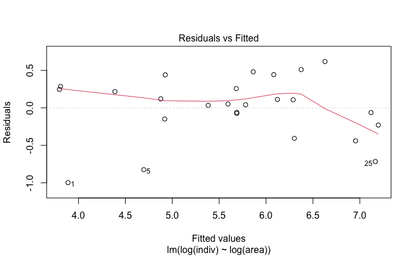

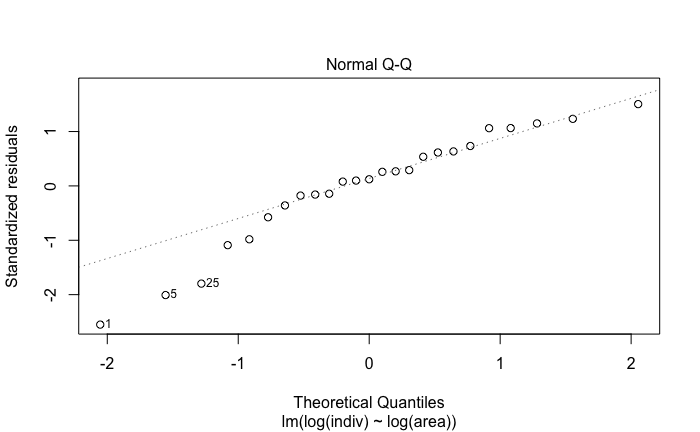

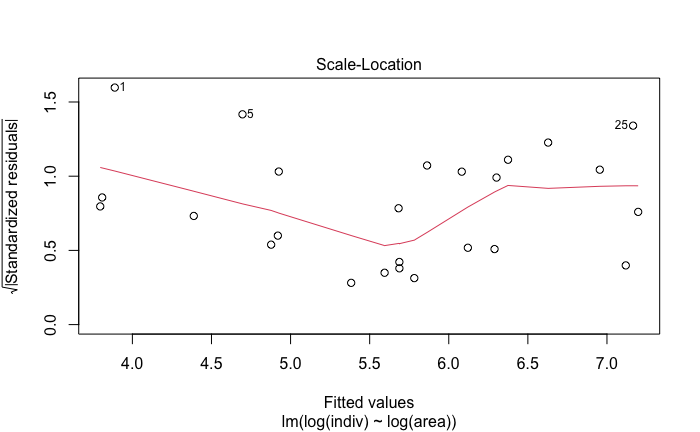

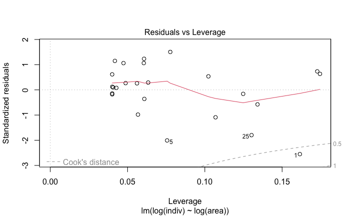

```r
lm5 <- lm(log(indiv) ~ log(area), data = df)
plot(lm5)
```

> Relationship looks OK now

## Study C

In Chapter 4’s exercises, you should have described a model to fit to these data.

**What are the assumptions associated with that model?**

> Normality (maybe), homogeneity of variances, independence

**Read in the data and check the assumptions**

```r
df <- read.csv("data/vosteen.csv")
head(df,10)
```

|  | clone_plant_combination | honeydew | clone | plant | hostplant |
| --- | --- | --- | --- | --- | --- |
| 1 | T_Vicia | 1.08 | T | Vicia | Universal |
| 2 | T_Vicia | 2.21 | T | Vicia | Universal |
| 3 | T_Vicia | 2.63 | T | Vicia | Universal |
| 4 | T_Vicia | 1.63 | T | Vicia | Universal |
| 5 | T_Vicia | 3.51 | T | Vicia | Universal |
| 6 | T_Vicia | 2.53 | T | Vicia | Universal |
| 7 | T_Vicia | 2.92 | T | Vicia | Universal |
| 8 | T_Vicia | 0.98 | T | Vicia | Universal |
| 9 | T_Vicia | 2.39 | T | Vicia | Universal |
| 10 | T_Vicia | 2.05 | T | Vicia | Universal |

> Boxplots; not perfect, with small sample sizes. Try also fit linear model and look at residuals

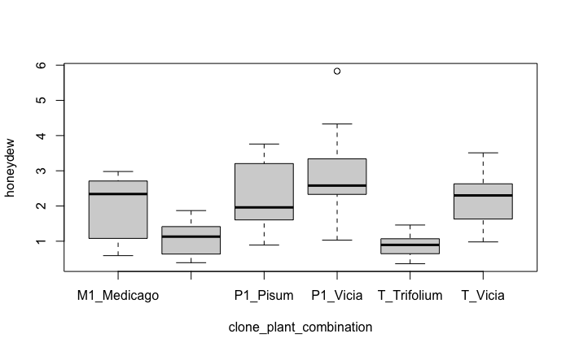

```r
boxplot(data = df, honeydew ~ clone_plant_combination)
```

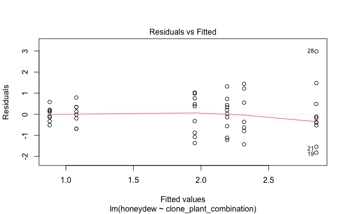

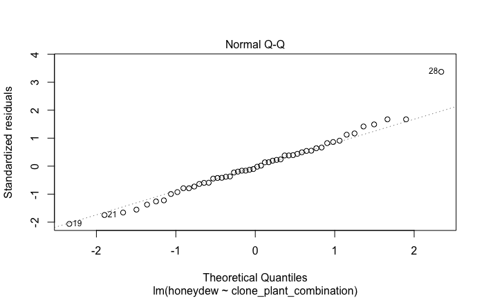

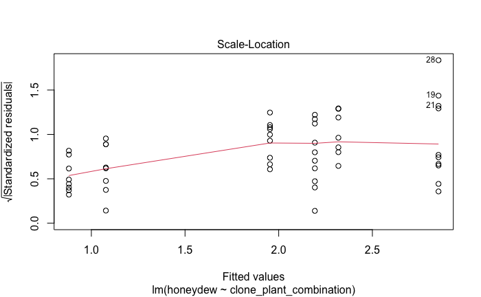

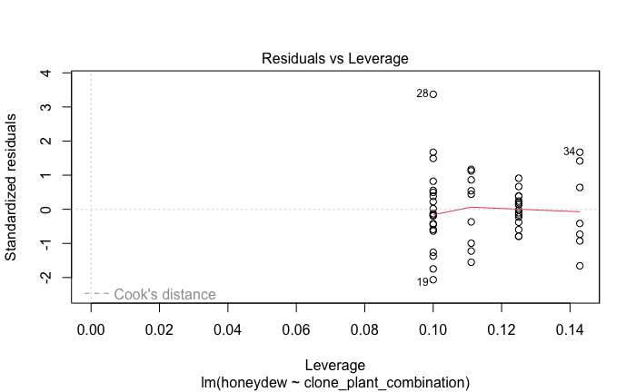

```r
lm <- lm(data = df, honeydew ~ clone_plant_combination)
plot(lm)
```

```r
augment(lm)
```

| honeydew | clone_plant_combination | .fitted | .resid | .hat | .sigma | .cooksd | .std.resid |
| --- | --- | --- | --- | --- | --- | --- | --- |
| 1.08 | T_Vicia | 2.19 | -1.1130 | 0.100 | 0.925 | 2.94e-02 | -1.2602 |
| 2.21 | T_Vicia | 2.19 | 0.0170 | 0.100 | 0.941 | 6.86e-06 | 0.0192 |
| 2.63 | T_Vicia | 2.19 | 0.4370 | 0.100 | 0.939 | 4.53e-03 | 0.4948 |
| 1.63 | T_Vicia | 2.19 | -0.5630 | 0.100 | 0.937 | 7.53e-03 | -0.6375 |
| 3.51 | T_Vicia | 2.19 | 1.3170 | 0.100 | 0.918 | 4.12e-02 | 1.4912 |
| 2.53 | T_Vicia | 2.19 | 0.3370 | 0.100 | 0.940 | 2.70e-03 | 0.3816 |
| 2.92 | T_Vicia | 2.19 | 0.7270 | 0.100 | 0.934 | 1.25e-02 | 0.8232 |
| 0.98 | T_Vicia | 2.19 | -1.2130 | 0.100 | 0.922 | 3.49e-02 | -1.3735 |
| 2.39 | T_Vicia | 2.19 | 0.1970 | 0.100 | 0.941 | 9.21e-04 | 0.2231 |
| 2.05 | T_Vicia | 2.19 | -0.1430 | 0.100 | 0.941 | 4.85e-04 | -0.1619 |

[output cut: 42 more lines]

> Some hint of variance heterogeneity, and one point (record 28) that may worth looking at, as it’s a very high value with a slightly higher Cook’s D